# *University of Houston Downtown (UHD)*

Quang Le

# **Mission and Vision**

01 February, 2025

[figure not shown]

*Note: Please review my mission and vision as a Supplemental Instruction Leader at [UHD SI Program](https://www.uhd.edu/sssl/supplemental-instruction/index.aspx).*

# **A. Mission**

## *1. Foster Collaborative Learning*

- As an *SI leader*, my mission is to:
1. Create an inclusive and supportive environment for students.
2. Facilitate group discussion, peer teaching, and collaborative problem-solving activities.
3. Support students understand the lessons and material deeply through learning from each others perspectives.

## *2. Enhance Academic Skills*

- My role involves equipping students with:
1. Develop effective study strategies and academic techniques in each SI sessions.
2. Encourage students to actively participate and help each others during sessions.
3. Utilize various learning resources and tools to accommodate different learning styles and needs.

## *3. Clarification and Reinforcement*

- One of my key tasks is to:
1. Help students overcome complicated concepts by simplifying it into straight-forwarded concepts.
2. Reinforce students to understand the course lesson or materials by using innovative method teaching styles.

## *4.Cultivate a Growth Mindset*

- Quang Le is encourage students to adopt a growth mindset by:
1. Promoting the belief that abilities and intelligence can be developed through dedication and hard work.
2. Providing constructive feedback and celebrating students’ progress, reinforcing the idea that effort leads to improvement.
3. Motivating students to embrace challenges and view setbacks as opportunities for learning and growth.

# **B. Vision**

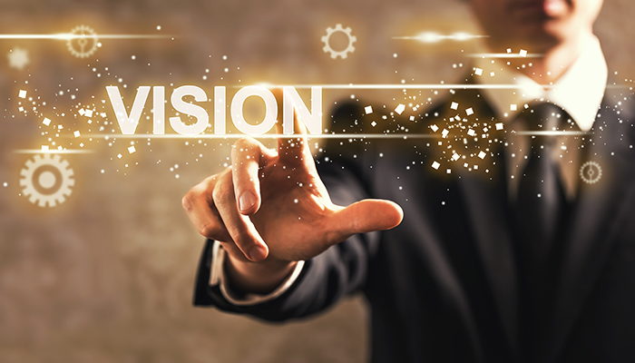

## *1. Slogan*

*EICGA - Empowerment, Innovation, Community, Growth, Accessibility*

## *2. Core values*

*a. Empowerment* - *Empower students to take ownership of their learning and achieve academic excellence through collaborative and inclusive sessions.*

*b. Innovation* - *Foster an innovative learning environment that leverages diverse teaching methods and resources to accommodate different learning styles.*

*c. Community* - *Build a supportive and connected learning community where students feel valued, encouraged, and motivated to succeed.*

*d. Growth* - *Inspire a culture of continuous growth and improvement, where students develop not only academically but also personally and professionally.*

*e. Accessibility* - *Ensure that all students have equal access to the support and resources they need to thrive in their academic pursuits.*

## *3. Vision Statement*

*"As an SI leader, I, Quang Le, aim to empower students to achieve greater success by taking ownership of their learning and embracing collaborative problem-solving for improved outcomes, not just better exam grades. I aim to create an innovative and inclusive environment that highlights the benefits of working together, leading to deeper understanding and personal growth. My goal is to provide equal access to support and resources, ensuring all students can thrive both academically and personally."*

> *From Quang Le*

© 2025 Quang Le | [University of Houston - Downtown | [UHD Supplemental Instruction](https://www.uhd.edu/sssl/supplemental-instruction/index.aspx)](https://www.uhd.edu)